# HW 4 Explore a Single Variable - Guide

Henry Lin

```r
library(dplyr)
library(ggplot2)
library(janitor)
library(kableExtra)
```

```r
theme_update(plot.title = element_text(hjust = 0.5))
```

```r
load("/cloud/project/data/mydata.Rdata")
load("/cloud/project/data/clean.Rdata")
```

# Table of Variables

| Original Variable (from addhealth) | New Variable | Categorical or Numerical | Description (from addhealth) |
| --- | --- | --- | --- |
| H4LM20 | time_of_day_worked | Categorical | Which one of these categories best describes the hours you (work/worked) at this job? |
| H4LM17 | separation_cause | Categorical | What is the main reason you left your most recent job? |
| H4LM26 | job_satisfaction | Categorical | How satisfied (are/were) you with this job? |
| H4LM14 | current_status | Categorical | Which one of the following categories best describes what you’re doing now? |
| H4LM28 | family_impact_on_work | Categorical | Indicate how much you would agree or disagree with this statement: Family responsibilities have interfered with my ability to work. |
| H4LM30 | work_impact_family_time | Categorical | (In the past 12 months/Since you started your current job/In the last year of your most recent job), how often on your primary job (have you spent/have you spent/did you spend) less time with your fam… |
| H4LM19 | hours_worked | Numerical | How many hours a week (do/did) you usually work at this job? |
| H4LM12 | number_of_jobs_worked | Numerical | On how many jobs are you currently working for pay at least 10 hours a week? |

# Examing categorical variables

## 1st Categorical `time_of_day_worked`

**Numerical Summary Table**

```r
time_of_day_worked<-mydata %>%

  filter(time_of_day_worked %in% c ("regular day", "regular evening", "regular night", "shift rotates", "split shift", "irregular schedule or hours", "other")) %>%
  droplevels() %>%

  tabyl(time_of_day_worked) %>%
  adorn_pct_formatting(digits=1) %>%
  adorn_totals()

time_of_day_worked %>%
  kable() %>%
  kable_styling(full_width = F, position="center")
```

time_of_day_worked

n

percent

regular day

3319

66.0%

regular evening

364

7.2%

regular night

296

5.9%

shift rotates

446

8.9%

split shift

78

1.6%

irregular schedule or hours

470

9.3%

other

54

1.1%

Total

5027

**Bar Plot - Frequency of Levels**

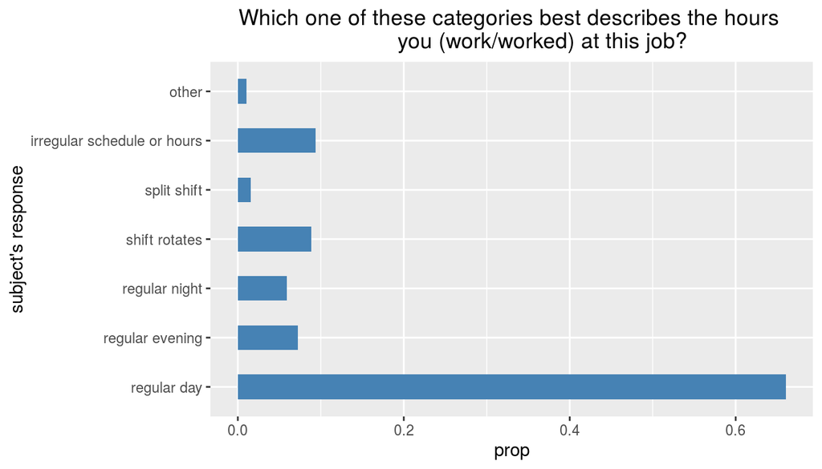

```r
mydata %>%
  #filter(time_of_day_worked=="yes" | time_of_day_worked=="no") %>%
  filter(time_of_day_worked %in% c ("regular day", "regular evening", "regular night", "shift rotates", "split shift", "irregular schedule or hours", "other")) %>%
  ggplot(aes(x=time_of_day_worked, y= ..prop.., group=1))+
  geom_bar(fill="steelblue", width=0.5)+
  ggtitle("Which one of these categories best describes the hours
          you (work/worked) at this job?") +
  xlab("subject's response")+
coord_flip()
```

**Narrative summary**

The participants in the **addhealth** study were asked, “*Which one of these categories best describes the hours you (work/worked) at this job?*” **5027** out of **5114** provided a response as to which hours they work, with the options being “regular day shift”, “regular evening shift”, “regular night shift”, “shift rotates”, split shift“,”irregular schedule or hours“, or”otheir" with approximately **65%** of the participants responding **regular day shift**. Approximately **2 out of 3** participants work day shifts.

## 2nd Categorical `separation_cause`

**Numerical Summary Table**

```r
separation_cause <- mydata %>%

  filter(separation_cause %in% c ("layoff", "plant closed", "end of temporary or seasonal job", "discharged or fired", "program ended", "health prolems", "pregnancy or family reasons", "return to school", "quit to look for another job", "quit to take another job", "retired", "military service", "incarceration", "other")) %>%
  droplevels() %>%

  tabyl(separation_cause) %>%
  adorn_pct_formatting(digits=1) %>%
  adorn_totals()
separation_cause %>%
  kable() %>%
  kable_styling(full_width = F, position="center")
```

separation_cause

n

percent

layoff

66

9.2%

plant closed

12

1.7%

end of temporary or seasonal job

34

4.7%

discharged or fired

45

6.2%

program ended

13

1.8%

pregnancy or family reasons

154

21.4%

return to school

103

14.3%

quit to look for another job

49

6.8%

quit to take another job

15

2.1%

retired

1

0.1%

military service

48

6.7%

incarceration

14

1.9%

other

166

23.1%

Total

720

**Bar Plot - Frequency of Levels**

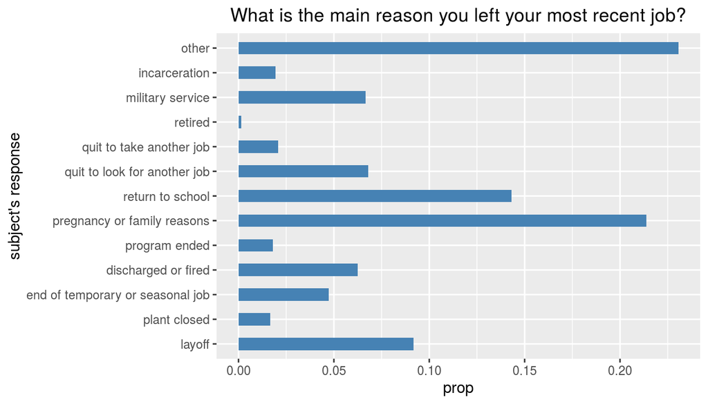

```r
mydata %>%
  #filter(separation_cause=="yes" | separation_cause=="no") %>%
  filter(separation_cause %in% c ("layoff", "plant closed", "end of temporary or seasonal job", "discharged or fired", "program ended", "health prolems", "pregnancy or family reasons", "return to school", "quit to look for another job", "quit to take another job", "retired", "military service", "incarceration", "other")) %>%
  ggplot(aes(x=separation_cause, y= ..prop.., group=1))+
  geom_bar(fill="steelblue", width=0.5)+
  ggtitle("What is the main reason you left your most recent job?") +
  xlab("subject's response")+
  coord_flip()
```

**Narrative summary**

## 3rd Categorical `job_satisfaction`

**Numerical Summary Table**

```r
job_satisfaction <- mydata %>%

  filter(job_satisfaction %in% c ("extremely satisfied", "satisfied", "neither satisfied nor dissatisfied", "dissatisfied", "extremely dissatisfied", "refused")) %>%
  droplevels() %>%

  tabyl(job_satisfaction) %>%
  adorn_pct_formatting(digits=1) %>%
  adorn_totals()
job_satisfaction %>%
  kable() %>%
  kable_styling(full_width = F, position="center")
```

job_satisfaction

n

percent

extremely satisfied

1188

23.6%

satisfied

2505

49.8%

neither satisfied nor dissatisfied

884

17.6%

dissatisfied

329

6.5%

extremely dissatisfied

118

2.3%

refused

3

0.1%

Total

5027

**Bar Plot - Frequency of Levels**

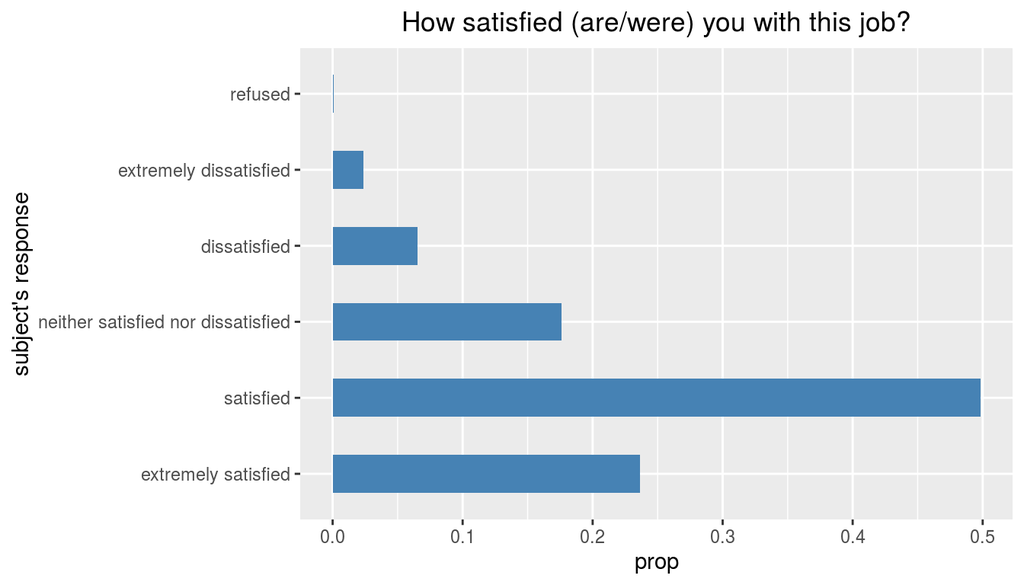

```r
mydata %>%
  #filter(job_satisfaction=="yes" | job_satisfaction=="no") %>%
  filter(job_satisfaction %in% c ("extremely satisfied", "satisfied", "neither satisfied nor dissatisfied", "dissatisfied", "extremely dissatisfied", "refused")) %>%
  ggplot(aes(x=job_satisfaction, y= ..prop.., group=1))+
  geom_bar(fill="steelblue", width=0.5)+
  ggtitle("How satisfied (are/were) you with this job?") +
  xlab("subject's response")+
  coord_flip()
```

**Narrative summary**

The participants in the **addhealth** study were asked, “*How satisfied (are/were) you with this job?*” **5024** out of **5027** provided a response as to their job satisfaction, with the options being “extremely satisfied”, “satisfied”, “neitheir satisfied nor dissatisfied”, “dissatisfied”, or “extremely dissatisfied”, with approximately **75%** of the participants responding **satisfied or higher**. Approximately **3 out of 4** participants were at least satisfied with their work.

## 4th Categorical `current_status`

**Numerical Summary Table**

```r
current_status <- mydata %>%

  filter(current_status %in% c("only temporarily laid off","on sick leave or temporarily disabled", "on maternity/paternity leave", "permanently disabled", "unemployed and looking for work", "unemployed and looking for work", "student", "keeping house", "retired", "other")) %>%
  droplevels() %>%

  tabyl(current_status) %>%
  adorn_pct_formatting(digits=1) %>%
  adorn_totals()
current_status %>%
  kable() %>%
  kable_styling(full_width = F, position="center")
```

current_status

n

percent

only temporarily laid off

61

6.7%

on sick leave or temporarily disabled

33

3.6%

on maternity/paternity leave

23

2.5%

permanently disabled

53

5.8%

unemployed and looking for work

260

28.5%

student

161

17.6%

keeping house

252

27.6%

retired

1

0.1%

other

69

7.6%

Total

913

**Bar Plot - Frequency of Levels**

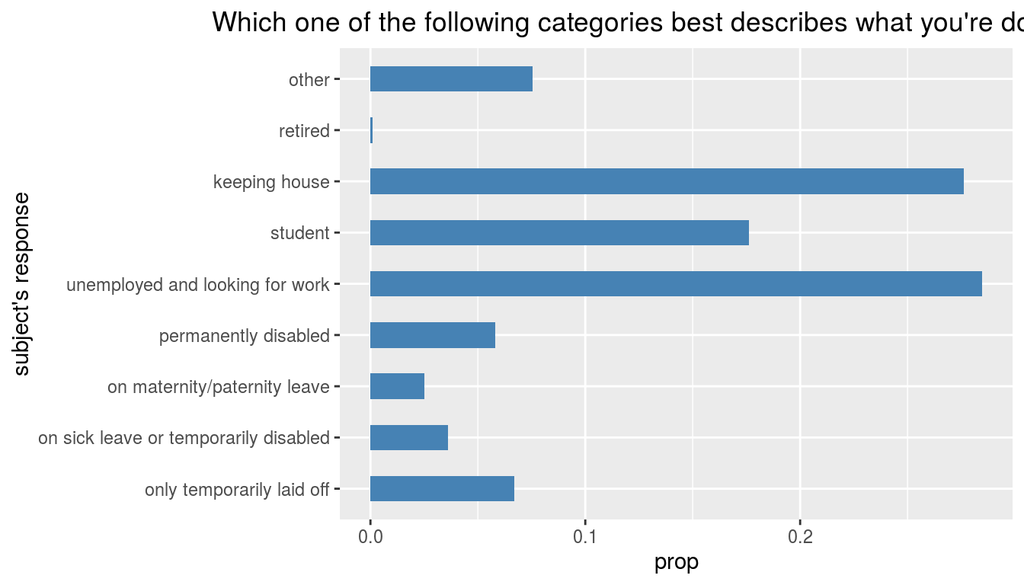

```r
mydata %>%
  #filter(current_status=="yes" | current_status=="no") %>%
  filter(current_status %in% c("only temporarily laid off","on sick leave or temporarily disabled", "on maternity/paternity leave", "permanently disabled", "unemployed and looking for work", "unemployed and looking for work", "student", "keeping house", "retired", "other")) %>%  ggplot(aes(x=current_status, y= ..prop.., group=1))+
  geom_bar(fill="steelblue", width=0.5)+
  ggtitle("Which one of the following categories best describes what you're doing now?") +
  xlab("subject's response")+
coord_flip()
```

**Narrative summary**

## 5th Categorical `family_impact_on_work`

**Numerical Summary Table**

```r
family_impact_on_work <- mydata %>%

  filter(family_impact_on_work %in% c("strongly agree", "agree", "neither agree or disagree", "disagree", "strongly disagree")) %>%
  droplevels() %>%

  tabyl(family_impact_on_work) %>%
  adorn_pct_formatting(digits=1) %>%
  adorn_totals()
family_impact_on_work %>%
  kable() %>%
  kable_styling(full_width = F, position="center")
```

family_impact_on_work

n

percent

strongly agree

301

5.9%

agree

540

10.6%

neither agree or disagree

553

10.8%

disagree

1893

37.1%

strongly disagree

1818

35.6%

Total

5105

**Bar Plot - Frequency of Levels**

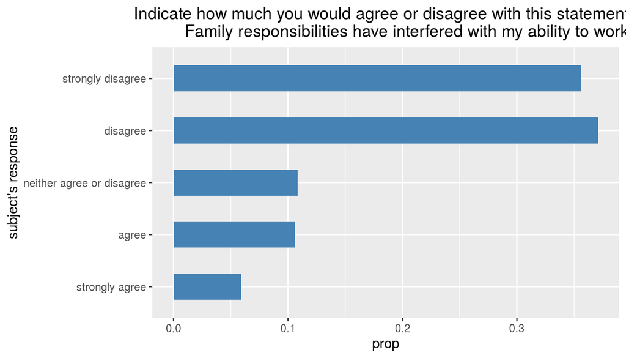

```r
mydata %>%
  #filter(family_impact_on_work=="yes" | family_impact_on_work=="no") %>%
  filter(family_impact_on_work %in% c("strongly agree", "agree", "neither agree or disagree", "disagree", "strongly disagree")) %>%
  ggplot(aes(x=family_impact_on_work, y= ..prop.., group=1))+
  geom_bar(fill="steelblue", width=0.5)+
  ggtitle("Indicate how much you would agree or disagree with this statement:
          Family responsibilities have interfered with my ability to work.") +
  xlab("subject's response")+
  coord_flip()
```

## 6th Categorical `work_impact_family_time`

**Numerical Summary Table**

```r
work_impact_family_time <- mydata %>%

  filter(work_impact_family_time %in% c("frequently", "sometimes", "rarely", "never")) %>%
  droplevels() %>%

  tabyl(work_impact_family_time) %>%
  adorn_pct_formatting(digits=1) %>%
  adorn_totals()
work_impact_family_time %>%
  kable() %>%
  kable_styling(full_width = F, position="center")
```

work_impact_family_time

n

percent

frequently

718

14.3%

sometimes

1446

28.8%

rarely

874

17.4%

never

1988

39.6%

Total

5026

**Bar Plot - Frequency of Levels**

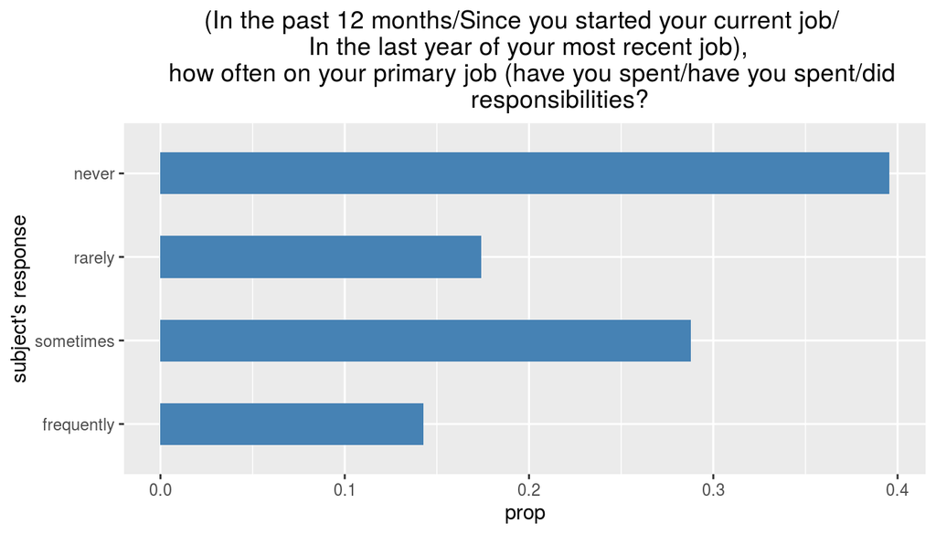

```r
mydata %>%
  #filter(work_impact_family_time=="yes" | work_impact_family_time=="no") %>%
  filter(work_impact_family_time %in% c("frequently", "sometimes", "rarely", "never")) %>%
  ggplot(aes(x=work_impact_family_time, y= ..prop.., group=1))+
  geom_bar(fill="steelblue", width=0.5)+

  ggtitle("(In the past 12 months/Since you started your current job/
  In the last year of your most recent job),
  how often on your primary job (have you spent/have you spent/did
          responsibilities?") +
  xlab("subject's response")+
  coord_flip()
```

**Narrative summary**

# Examining numerical variable

## 1st Numerical `hrs_work_week`

**Numerical Summary Table**

```r
hours_worked <- mydata %>%
  filter(hours_worked < 121) %>%
  summarize(n = n(),
            min = min(hours_worked ),
            q1 = quantile(hours_worked , probs=0.25),
            median = median(hours_worked ),
            mean = mean(hours_worked ),
            q3 = quantile(hours_worked , probs=0.75),
            max = max(hours_worked ),
            sd = sd(hours_worked ))

kable(round(hours_worked,1)) %>%
kable_styling(full_width = F, position="center")
```

| n | min | q1 | median | mean | q3 | max | sd |
| --- | --- | --- | --- | --- | --- | --- | --- |
| 5023 | 10 | 40 | 40 | 41.2 | 45 | 120 | 11.4 |

**Histogram - visualization of the distribution**

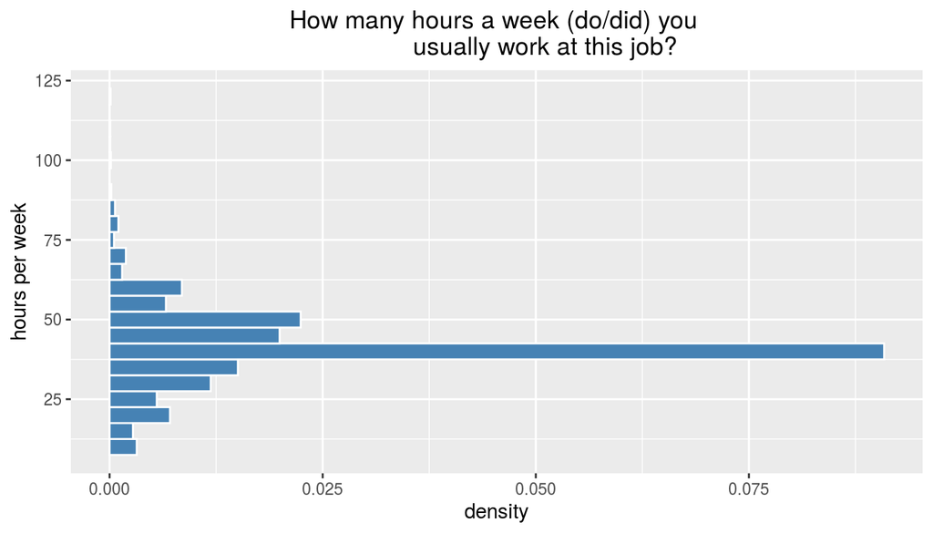

```r
mydata %>%
  filter(hours_worked  < 121) %>%
  ggplot(aes(x=hours_worked )) +
    geom_histogram(aes(y=..density..), color="white", fill="steelblue", binwidth = 5) +
      xlab("hours per week") +
      ggtitle("How many hours a week (do/did) you
              usually work at this job?") +
  coord_flip()
```

**Boxplot - visualization of 5 number summary**

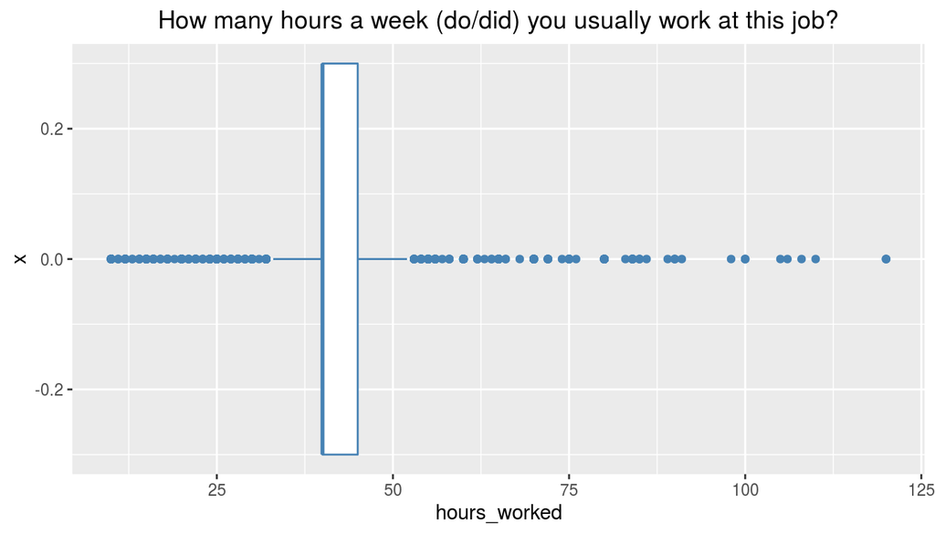

```r
mydata %>%
  filter(hours_worked  < 121) %>%
  ggplot(aes(y=hours_worked , x=0)) +
    geom_boxplot(color="steelblue", width=0.6) +
      ggtitle("How many hours a week (do/did) you usually work at this job?")+
  coord_flip()
```

**Narrative Summary**

Participants were asked, in reference to their current or most recent job (which they work more than 10 hours/week), “*How many hours a week (do/did) you usually work at this job?*”

- **5023** out of **5114** responded with hours between 10 and 120.
- **82** participants were a **legitimate skip** since they have not worked a paying job for at least 10 hours a week, they are not represented here.

The center of the distribution is best described with the **mode** and **median** of 40 hours/week. theire is considerable overall variation as hours vary from 10 to 120, although the middle 50% of particpants are between 40 and 45 hours, for an interquartile range (**IQR**) of 5 hours. Weekly work hours is *slightly skewed to the **right*** (since outliers extend, to the right, to 120 hours). This skew also results in the **mean** being greater than the **median**, which is a typically characteristic of right skewed distributions.

## 2nd Numerical `number_of_jobs`

**Numerical Summary Table**

```r
number_of_jobs <- mydata %>%
  filter(number_of_jobs_worked < 13) %>%
  summarize(n = n(),
            min = min(number_of_jobs_worked ),
            q1 = quantile(number_of_jobs_worked , probs=0.25),
            median = median(number_of_jobs_worked ),
            mean = mean(number_of_jobs_worked ),
            q3 = quantile(number_of_jobs_worked , probs=0.75),
            max = max(number_of_jobs_worked ),
            sd = sd(number_of_jobs_worked ))

kable(round(number_of_jobs,1)) %>%
kable_styling(full_width = F, position="center")
```

| n | min | q1 | median | mean | q3 | max | sd |
| --- | --- | --- | --- | --- | --- | --- | --- |
| 4093 | 1 | 1 | 1 | 1.1 | 1 | 12 | 0.4 |

**Histogram - visualization of the distribution**

[figure not shown]

```r
mydata %>%
  filter(number_of_jobs_worked  < 13) %>%
  ggplot(aes(x=number_of_jobs_worked )) +
    geom_histogram(aes(y=..density..), color="white", fill="steelblue", binwidth = 5) +
      xlab("hours per week") +
      ggtitle("How many hours a week (do/did) you
              usually work at this job?") +
  coord_flip()
```

**Boxplot - visualization of 5 number summary**

[figure not shown]

```r
mydata %>%
  filter(number_of_jobs_worked  < 13) %>%
  ggplot(aes(y=number_of_jobs_worked , x=0)) +
    geom_boxplot(color="steelblue", width=0.6) +
      ggtitle("How many hours a week (do/did) you usually work at this job?")+
  coord_flip()
```

**Narrative Summary**

Participants were asked, “*On how many jobs are you currently working for pay at least 10 hours a week?*”

```r
save(current_status, file = "/cloud/project/data/current_status.Rdata")
save(family_impact_on_work, file = "/cloud/project/data/family_impact_on_work.Rdata")
save(hours_worked, file = "/cloud/project/data/hours_worked.Rdata")
save(job_satisfaction, file = "/cloud/project/data/job_satisfaction.Rdata")
save(number_of_jobs, file = "/cloud/project/data/number_of_jobs.Rdata")
save(separation_cause, file = "/cloud/project/data/seperation_cause.Rdata")
save(time_of_day_worked, file = "/cloud/project/data/time_of_day_worked.Rdata")
save(work_impact_family_time, file = "/cloud/project/data/work_impact_family_time.Rdata")
```